# Зелимхан Гудиев. Лабораторная №4

2022-11-01

# Лабораторная работа по теме «Анализ социальных сетей»

2. Создайте граф на основе данных об актерах, таким образом, чтобы в качестве рёбер графа использовались фильмы:

```r
library(igraph)
set.seed(100)
myGraph <- graph_from_data_frame(d = movies, vertices = actors, directed = F)
```

3. Используя цветовую кодировку, изобразите актеров, игравших совместно в фильме The Rock, и постройте полученный граф:

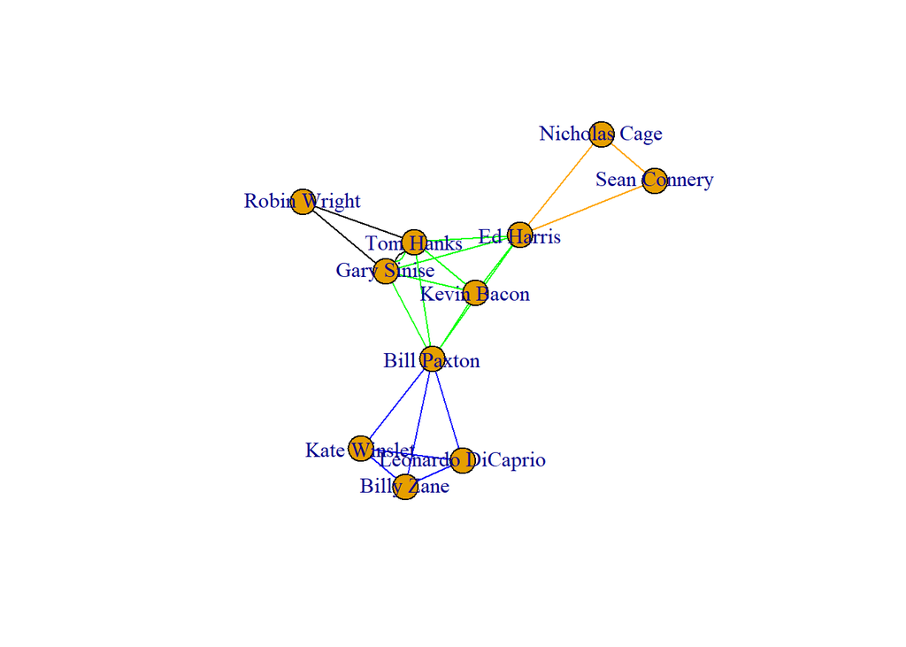

```r
movies <- E(myGraph)$Movie
E(myGraph)$color <- case_when(movies == "The Rock" ~ "orange",
                              movies == "Apollo 13" ~ "green",
                              movies == "Forrest Gump" ~ "black",
                              movies == "Titanic"~ "blue")

plot(myGraph)
```

Сделайте выводы.  
**Ответ:**  
*Актеры, игравшие в фильме The Rock, соединены ребрами оранжевого цвета - это Ed Harris, Sean Connery, Nicholas Cage.*

4. Добавьте на граф две легенды: выделение цветом полученных совместных связей из предыдущего задания и выделение цветом номинантов на лучшего актера/актрису и победителей:

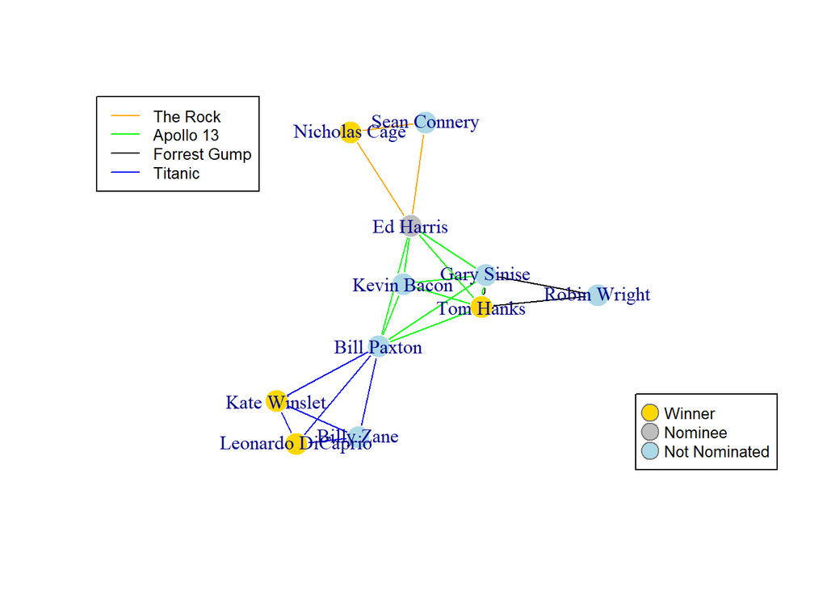

```r
win_colors <- ifelse(actors$BestActorActress == "Winner", "gold",
                     ifelse(actors$BestActorActress == "Nominated", "gray",
                            "lightblue"))

plot(myGraph, vertex.frame.color = "white", vertex.color = win_colors)

legend("bottomright", c("Winner","Nominee", "Not Nominated"), pch=21,
    col = "#777777", pt.bg = c("gold","grey","lightblue"), pt.cex = 2, cex = .8)

legend("topleft", c("The Rock", "Apollo 13", "Forrest Gump", "Titanic"),
    col = c("orange","green","black", "blue"), lty = 1, cex = .8)
```

5. Вычислите и представьте степени центральности (centrality):

```r
degree(myGraph, mode = "all") %>% sort()
```

```
##      Robin Wright      Sean Connery     Nicholas Cage Leonardo DiCaprio
##                 2                 2                 2                 3
##      Kate Winslet        Billy Zane       Kevin Bacon         Tom Hanks
##                 3                 3                 4                 6
##       Gary Sinise         Ed Harris       Bill Paxton
##                 6                 6                 7
```

Укажите актеров с наименьшей центральностью. Сделайте выводы. В частности, что означает центральность в данном случае с точки зрения ролей в фильмах?  
**Ответ:**  
*Актеры с наименьшей центральностью: Robin Wright, Sean Connery, Nicholas Cage. Эти актеры сыграли в одном фильме с наименьшим количеством других актеров. Центральность характеризует количество пересечений (социальных взаимодействий) с другмими актерами на съемочных площадках.*

6. Вычислите относительные степени близости (closeness):

```r
closeness(myGraph, mode = "all", weights = NA, normalized = T) %>%
  sort(decreasing = TRUE)
```

```
##       Bill Paxton         Ed Harris         Tom Hanks       Gary Sinise
##         0.7692308         0.7142857         0.6666667         0.6666667
##       Kevin Bacon Leonardo DiCaprio      Kate Winslet        Billy Zane
##         0.6250000         0.5000000         0.5000000         0.5000000
##      Sean Connery     Nicholas Cage      Robin Wright
##         0.4545455         0.4545455         0.4347826
```

Интерпретируйте полученные результаты. В частности, укажите актера с наибольшей степенью близости к другим узлам графа.

**Ответ:**  
*Актер с наибольшей степенью близости - Bill Paxton.*

Какова звенность (сколько звеньев (ребер графа) необходимо пройти) у Билла Пакстона по отношению к:  
- Тому Хэнксу; **Ответ:** *- одно ребро*  
- Эду Харрису; **Ответ:** *- одно ребро*  
- Робину Райту; **Ответ:** *- два ребра*  
- Николасу Кейджу; **Ответ:** *- два ребра*  
- Шону Коннери **Ответ:** *- два ребра*  
Есть ли актеры со звенностью более 2? Если да, укажите по крайней мере одного актера и такую связь.  
**Ответ:** *Для Билла Пакстона актеров со звенностью более 2-х нет. Но, например, для Николоса Кейджа чтобы добраться до Кейт Уинслетт нужно пройти три ребра: Nicholas Cage ->1-> Ed Harris ->2-> Bill Paxton ->3-> Kate Winslet.*  
Есть ли актеры со звенностью более 3?  
**Ответ:** *Таких актеров нет.*

7. Вычислите степени посредничества (betweenness):

```r
betweenness(myGraph, directed = F, weights = NA, normalized = T) %>%
  sort(decreasing = TRUE)
```

```
##       Bill Paxton         Ed Harris         Tom Hanks       Gary Sinise
##        0.46666667        0.35555556        0.08888889        0.08888889
##      Robin Wright       Kevin Bacon      Sean Connery     Nicholas Cage
##        0.00000000        0.00000000        0.00000000        0.00000000
## Leonardo DiCaprio      Kate Winslet        Billy Zane
##        0.00000000        0.00000000        0.00000000
```

Существуют ли звенья (вершины) графа с высокой степенью посредничества, т.е. оказывающиеся на пути к другим звеньям, и, возможно, представляющие собой «узкие места» либо узловые точки передачи информации (возможно, фильтры)? Укажите этих актеров и их степень посредничества.  
**Ответ:** *Актерами с высокой степенью посредничества являются Bill Paxton (0.47) и Ed Harris(0.36).*  
В данном примере, обладают ли они высокой или низкой степенью центральности? Что это может означать?  
**Ответ:** *В данном примере актеры с высокой степенью посредничества являются также актерами с наибольшей центральностью. Это означает, что чем больше у вершины (актера) социальных связей, тем чаще она становится посредником между другими вершинами.*

8. Вычислите «критерий Бэйкона» для актеров Шона Коннери и какого-либо другого по выбору:

```r
distances(myGraph, v = V(myGraph)["Sean Connery"], to = V(myGraph), weights=NA)
```

```
##              Tom Hanks Gary Sinise Robin Wright Bill Paxton Kevin Bacon
## Sean Connery         2           2            3           2           2
##              Ed Harris Sean Connery Nicholas Cage Leonardo DiCaprio
## Sean Connery         1            0             1                 3
##              Kate Winslet Billy Zane
## Sean Connery            3          3
```

```r
distances(myGraph, v = V(myGraph)["Bill Paxton"], to = V(myGraph), weights = NA)
```

```
##             Tom Hanks Gary Sinise Robin Wright Bill Paxton Kevin Bacon
## Bill Paxton         1           1            2           0           1
##             Ed Harris Sean Connery Nicholas Cage Leonardo DiCaprio Kate Winslet
## Bill Paxton         1            2             2                 1            1
##             Billy Zane
## Bill Paxton          1
```